# Analyse des vulnérabilités ANSSI

Ce notebook charge le fichier CSV généré par le pipeline, explore les données, produit un ensemble de visualisations et applique des modèles de Machine Learning.

## 1. Chargement des données

```python
import pandas as pd
import numpy as np
import matplotlib.pyplot as plt
import matplotlib.dates as mdates
import seaborn as sns
from sklearn.cluster import KMeans
from sklearn.preprocessing import LabelEncoder, StandardScaler
from sklearn.ensemble import RandomForestClassifier
from sklearn.model_selection import train_test_split
from sklearn.metrics import classification_report, confusion_matrix, silhouette_score
from sklearn.decomposition import PCA

sns.set_theme(style='whitegrid')
plt.rcParams['figure.dpi'] = 100

df = pd.read_csv('donnees_enrichies.csv')

df['Score CVSS'] = pd.to_numeric(df['Score CVSS'], errors='coerce')
df['Score EPSS'] = pd.to_numeric(df['Score EPSS'], errors='coerce')
df['Date de publication'] = pd.to_datetime(df['Date de publication'], errors='coerce')

# Sous-ensembles propres
df_cvss = df.dropna(subset=['Score CVSS'])
df_epss = df.dropna(subset=['Score EPSS'])
df_deux = df.dropna(subset=['Score CVSS', 'Score EPSS'])
df_sev = df[df['Base Severity'].isin(['LOW','MEDIUM','HIGH','CRITICAL'])]

print(f'Lignes totales : {len(df)}')
print(f'Colonnes : {list(df.columns)}')
print(f'CVE avec CVSS : {len(df_cvss)}')
print(f'CVE avec EPSS : {len(df_epss)}')
```

```
Lignes totales : 187
Colonnes : ['ID ANSSI', 'Titre ANSSI', 'Type', 'Date de publication', 'Lien', 'Identifiant CVE', 'Score CVSS', 'Base Severity', 'Type CWE', 'Score EPSS', 'Description', 'Éditeur (Vendor)', 'Produit', 'Versions affectées']
CVE avec CVSS : 158
CVE avec EPSS : 186
```

## 2. Exploration du DataFrame

```python
df.head(10)
```

|  | ID ANSSI | Titre ANSSI | Type | Date de publication | Lien | Identifiant CVE | Score CVSS | Base Severity | Type CWE | Score EPSS | Description | Éditeur (Vendor) | Produit | Versions affectées |
| --- | --- | --- | --- | --- | --- | --- | --- | --- | --- | --- | --- | --- | --- | --- |
| 0 | CERTFR-2023-ALE-007 | [MàJ] Vulnérabilité dans Zimbra Collaboration ... | alerte | 2023-07-17 | https://www.cert.ssi.gouv.fr/alerte/CERTFR-202... | CVE-2023-37580 | NaN | Non renseigné | Non disponible | 0.93918 | Zimbra Collaboration (ZCS) 8 before 8.8.15 Pat... | NaN | NaN | NaN |
| 1 | CERTFR-2023-ALE-008 | [MàJ] Vulnérabilité dans Citrix NetScaler ADC ... | alerte | 2023-07-19 | https://www.cert.ssi.gouv.fr/alerte/CERTFR-202... | CVE-2023-3519 | 9.8 | CRITICAL | CWE-94 | 0.93363 | Unauthenticated remote code execution | Citrix | NetScaler ADC | 13.1, 13.0, 13.1-FIPS, 12.1-FIPS, 12.1-NDcPP |
| 2 | CERTFR-2023-ALE-008 | [MàJ] Vulnérabilité dans Citrix NetScaler ADC ... | alerte | 2023-07-19 | https://www.cert.ssi.gouv.fr/alerte/CERTFR-202... | CVE-2023-3519 | 9.8 | CRITICAL | CWE-94 | 0.93363 | Unauthenticated remote code execution | Citrix | NetScaler Gateway | 13.1, 13.0 |
| 3 | CERTFR-2023-ALE-010 | Multiples vulnérabilités dans Exim (02 octobre... | alerte | 2023-10-02 | https://www.cert.ssi.gouv.fr/alerte/CERTFR-202... | CVE-2023-42114 | 3.7 | LOW | CWE-125 | 0.13895 | Exim NTLM Challenge Out-Of-Bounds Read Informa... | Exim | Exim | exim 4.95 |
| 4 | CERTFR-2023-ALE-010 | Multiples vulnérabilités dans Exim (02 octobre... | alerte | 2023-10-02 | https://www.cert.ssi.gouv.fr/alerte/CERTFR-202... | CVE-2023-42115 | 9.8 | CRITICAL | CWE-787 | 0.65812 | Exim AUTH Out-Of-Bounds Write Remote Code Exec... | Exim | Exim | exim 4.95 |
| 5 | CERTFR-2023-ALE-010 | Multiples vulnérabilités dans Exim (02 octobre... | alerte | 2023-10-02 | https://www.cert.ssi.gouv.fr/alerte/CERTFR-202... | CVE-2023-42116 | 8.1 | HIGH | CWE-121 | 0.06734 | Exim SMTP Challenge Stack-based Buffer Overflo... | Exim | Exim | exim 4.95 |
| 6 | CERTFR-2023-ALE-010 | Multiples vulnérabilités dans Exim (02 octobre... | alerte | 2023-10-02 | https://www.cert.ssi.gouv.fr/alerte/CERTFR-202... | CVE-2023-42117 | 8.1 | HIGH | CWE-138 | 0.07350 | Exim Improper Neutralization of Special Elemen... | Exim | Exim | 4.96-RC1-11-315206fbf |
| 7 | CERTFR-2023-ALE-010 | Multiples vulnérabilités dans Exim (02 octobre... | alerte | 2023-10-02 | https://www.cert.ssi.gouv.fr/alerte/CERTFR-202... | CVE-2023-42118 | 7.5 | HIGH | CWE-191 | 0.03014 | Exim libspf2 Integer Underflow Remote Code Exe... | Exim | libspf2 | exim 4.96-RC0-14-24b8ed847-XX |
| 8 | CERTFR-2023-ALE-010 | Multiples vulnérabilités dans Exim (02 octobre... | alerte | 2023-10-02 | https://www.cert.ssi.gouv.fr/alerte/CERTFR-202... | CVE-2023-42119 | 3.1 | LOW | CWE-125 | 0.00731 | Exim dnsdb Out-Of-Bounds Read Information Disc... | Exim | Exim | exim 4.96-RC0-14-24b8ed847-XX |
| 9 | CERTFR-2023-ALE-011 | [MàJ] Multiples vulnérabilités dans Cisco IOS ... | alerte | 2023-10-17 | https://www.cert.ssi.gouv.fr/alerte/CERTFR-202... | CVE-2023-20198 | 10.0 | CRITICAL | CWE-420 | 0.94013 | Cisco is providing an update for the ongoing i... | Cisco | Cisco IOS XE Software | 16.1.1, 16.1.2, 16.1.3, 16.2.1, 16.2.2, 16.3.1... |

```python
df.describe()
```

|  | Date de publication | Score CVSS | Score EPSS |
| --- | --- | --- | --- |
| count | 187 | 158.000000 | 186.000000 |
| mean | 2026-01-11 13:51:39.465240576 | 6.861392 | 0.117089 |
| min | 2023-07-17 00:00:00 | 3.100000 | 0.000040 |
| 25% | 2026-06-09 00:00:00 | 6.100000 | 0.000150 |
| 50% | 2026-06-09 00:00:00 | 6.100000 | 0.000270 |
| 75% | 2026-06-10 00:00:00 | 7.800000 | 0.000588 |
| max | 2026-06-10 00:00:00 | 10.000000 | 0.944120 |
| std | NaN | 1.438184 | 0.298851 |

```python
print('Valeurs manquantes par colonne :')
print(df.isnull().sum())
print()
print('Répartition Type de bulletin :')
print(df['Type'].value_counts())
print()
print('Répartition Sévérité :')
print(df['Base Severity'].value_counts())
```

```
Valeurs manquantes par colonne :
ID ANSSI                0
Titre ANSSI             0
Type                    0
Date de publication     0
Lien                    0
Identifiant CVE         1
Score CVSS             29
Base Severity           1
Type CWE                1
Score EPSS              1
Description             1
Éditeur (Vendor)        2
Produit                 2
Versions affectées      2
dtype: int64

Répartition Type de bulletin :
Type
avis      157
alerte     30
Name: count, dtype: int64

Répartition Sévérité :
Base Severity
MEDIUM           86
HIGH             51
Non renseigné    28
CRITICAL         17
LOW               4
Name: count, dtype: int64
```

## 3. Visualisations

### 3.1 Distribution des scores CVSS

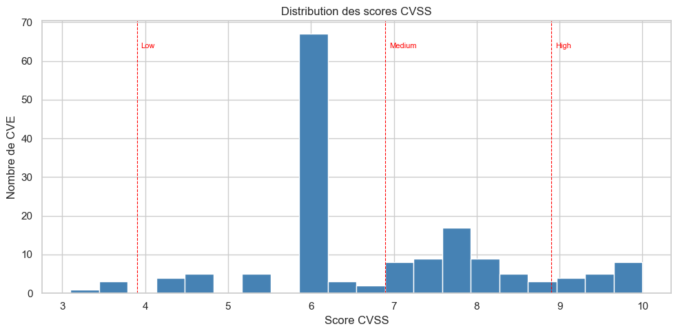

```python
fig, ax = plt.subplots(figsize=(10, 5))
ax.hist(df_cvss['Score CVSS'], bins=20, color='steelblue', edgecolor='white')
for x, label in [(3.9,'Low'), (6.9,'Medium'), (8.9,'High')]:
    ax.axvline(x, color='red', linestyle='--', linewidth=0.8)
    ax.text(x+0.05, ax.get_ylim()[1]*0.9, label, color='red', fontsize=8)
ax.set_title('Distribution des scores CVSS')
ax.set_xlabel('Score CVSS')
ax.set_ylabel('Nombre de CVE')
plt.tight_layout()
plt.savefig('graphique_cvss.png')
plt.show()
```

### 3.2 Distribution des scores EPSS

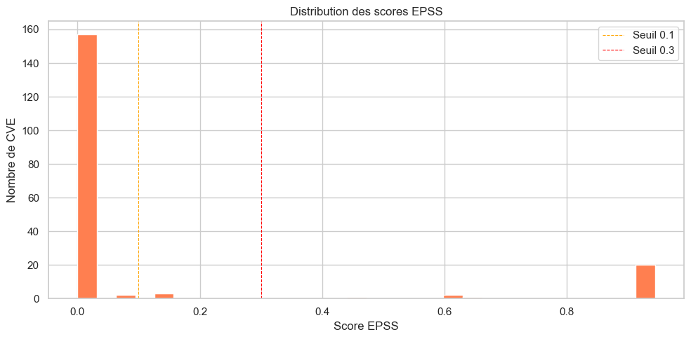

```
CVE avec EPSS > 0.3 : 24
```

```python
fig, ax = plt.subplots(figsize=(10, 5))
ax.hist(df_epss['Score EPSS'], bins=30, color='coral', edgecolor='white')
ax.axvline(0.1, color='orange', linestyle='--', linewidth=0.8, label='Seuil 0.1')
ax.axvline(0.3, color='red', linestyle='--', linewidth=0.8, label='Seuil 0.3')
ax.set_title('Distribution des scores EPSS')
ax.set_xlabel('Score EPSS')
ax.set_ylabel('Nombre de CVE')
ax.legend()
plt.tight_layout()
plt.savefig('graphique_epss.png')
plt.show()
print(f"CVE avec EPSS > 0.3 : {(df_epss['Score EPSS'] > 0.3).sum()}")
```

### 3.3 Répartition des niveaux de sévérité

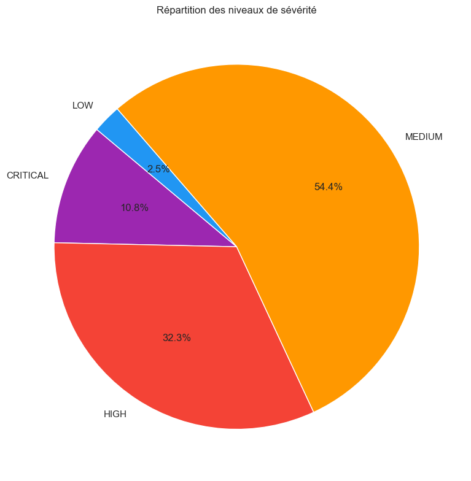

```python
couleurs_sev = {'LOW':'#2196F3','MEDIUM':'#FF9800','HIGH':'#F44336','CRITICAL':'#9C27B0'}
compte = df_sev['Base Severity'].value_counts()
ordre = [s for s in ['CRITICAL','HIGH','MEDIUM','LOW'] if s in compte.index]
compte = compte[ordre]
fig, ax = plt.subplots(figsize=(8, 8))
ax.pie(compte, labels=compte.index, autopct='%1.1f%%', startangle=140,
       colors=[couleurs_sev[s] for s in ordre])
ax.set_title('Répartition des niveaux de sévérité')
plt.tight_layout()
plt.savefig('graphique_severite.png')
plt.show()
```

### 3.4 Top 10 des éditeurs les plus touchés

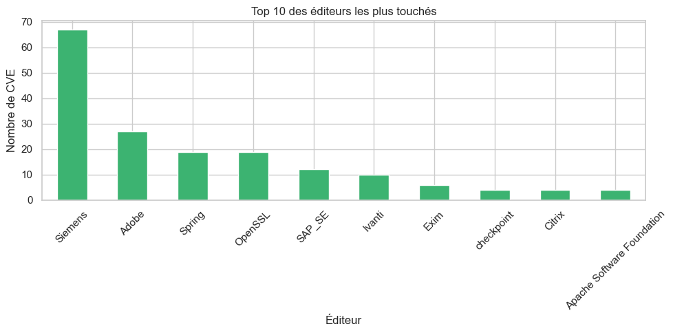

```python
top_vendors = df['Éditeur (Vendor)'].replace('n/a', pd.NA).dropna().value_counts().head(10)
fig, ax = plt.subplots(figsize=(10, 5))
top_vendors.plot(kind='bar', ax=ax, color='mediumseagreen', edgecolor='white')
ax.set_title('Top 10 des éditeurs les plus touchés')
ax.set_xlabel('Éditeur')
ax.set_ylabel('Nombre de CVE')
ax.tick_params(axis='x', rotation=45)
plt.tight_layout()
plt.savefig('graphique_vendors.png')
plt.show()
```

### 3.5 Top 10 des produits les plus touchés

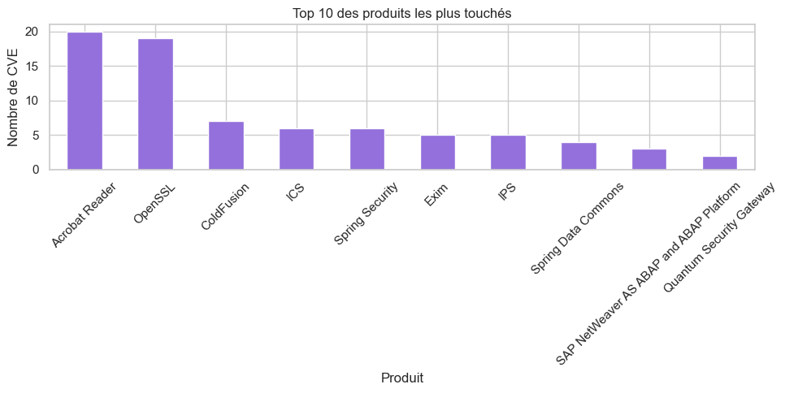

```python
top_produits = df['Produit'].replace('n/a', pd.NA).dropna().value_counts().head(10)
fig, ax = plt.subplots(figsize=(10, 5))
top_produits.plot(kind='bar', ax=ax, color='mediumpurple', edgecolor='white')
ax.set_title('Top 10 des produits les plus touchés')
ax.set_xlabel('Produit')
ax.set_ylabel('Nombre de CVE')
ax.tick_params(axis='x', rotation=45)
plt.tight_layout()
plt.savefig('graphique_produits.png')
plt.show()
```

### 3.6 Nuage de points : Score CVSS vs Score EPSS

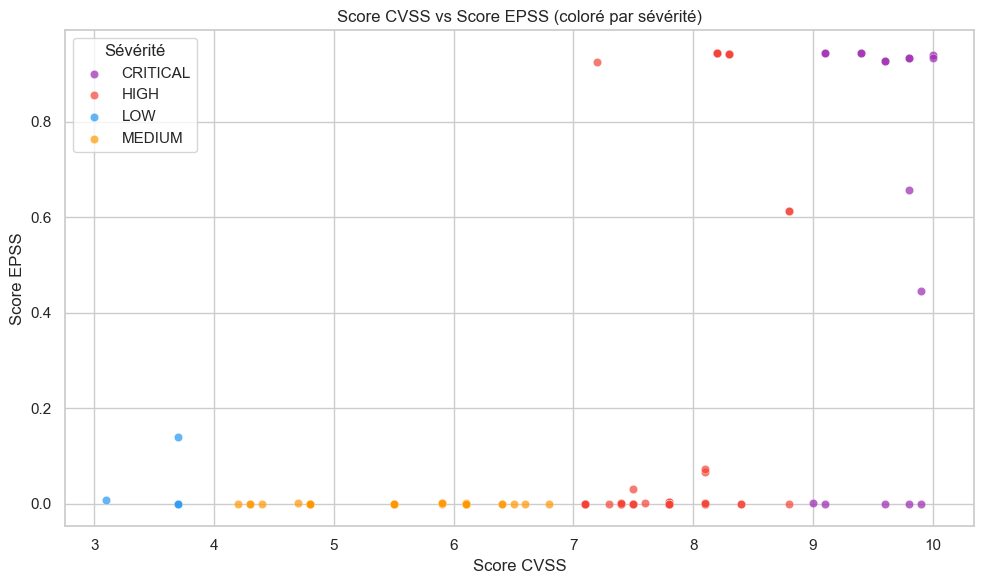

```python
couleurs_map = {'CRITICAL':'#9C27B0','HIGH':'#F44336','MEDIUM':'#FF9800','LOW':'#2196F3'}
df_plot = df_deux[df_deux['Base Severity'].isin(couleurs_map)].copy()
fig, ax = plt.subplots(figsize=(10, 6))
for sev, grp in df_plot.groupby('Base Severity'):
    ax.scatter(grp['Score CVSS'], grp['Score EPSS'], label=sev,
               color=couleurs_map[sev], alpha=0.7, edgecolors='white', linewidth=0.3)
ax.set_title('Score CVSS vs Score EPSS (coloré par sévérité)')
ax.set_xlabel('Score CVSS')
ax.set_ylabel('Score EPSS')
ax.legend(title='Sévérité')
plt.tight_layout()
plt.savefig('graphique_cvss_vs_epss.png')
plt.show()
```

### 3.7 Heatmap des corrélations (CVSS / EPSS)

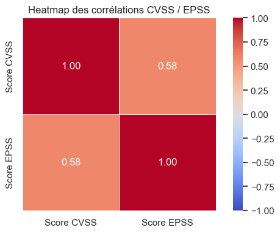

```
Corrélation CVSS-EPSS : 0.580
```

```python
corr = df_deux[['Score CVSS', 'Score EPSS']].corr()
fig, ax = plt.subplots(figsize=(6, 4))
sns.heatmap(corr, annot=True, fmt='.2f', cmap='coolwarm', ax=ax,
            linewidths=0.5, square=True, vmin=-1, vmax=1)
ax.set_title('Heatmap des corrélations CVSS / EPSS')
plt.tight_layout()
plt.savefig('graphique_heatmap.png')
plt.show()
print(f"Corrélation CVSS-EPSS : {corr.loc['Score CVSS','Score EPSS']:.3f}")
```

### 3.8 Boxplot des scores CVSS par éditeur (top 8)

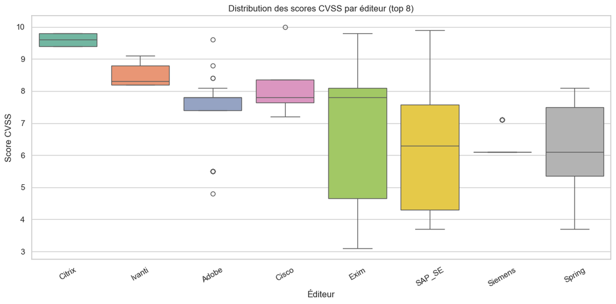

```python
top8 = df_cvss['Éditeur (Vendor)'].replace('n/a', pd.NA).dropna().value_counts().head(8).index
df_box = df_cvss[df_cvss['Éditeur (Vendor)'].isin(top8)]
fig, ax = plt.subplots(figsize=(12, 6))
order = (df_box.groupby('Éditeur (Vendor)')['Score CVSS']
         .median().sort_values(ascending=False).index)
sns.boxplot(data=df_box, x='Éditeur (Vendor)', y='Score CVSS',
            order=order, palette='Set2', ax=ax)
ax.set_title('Distribution des scores CVSS par éditeur (top 8)')
ax.set_xlabel('Éditeur')
ax.set_ylabel('Score CVSS')
ax.tick_params(axis='x', rotation=30)
plt.tight_layout()
plt.savefig('graphique_boxplot_vendors.png')
plt.show()
```

### 3.9 Évolution temporelle du nombre de CVE publiées

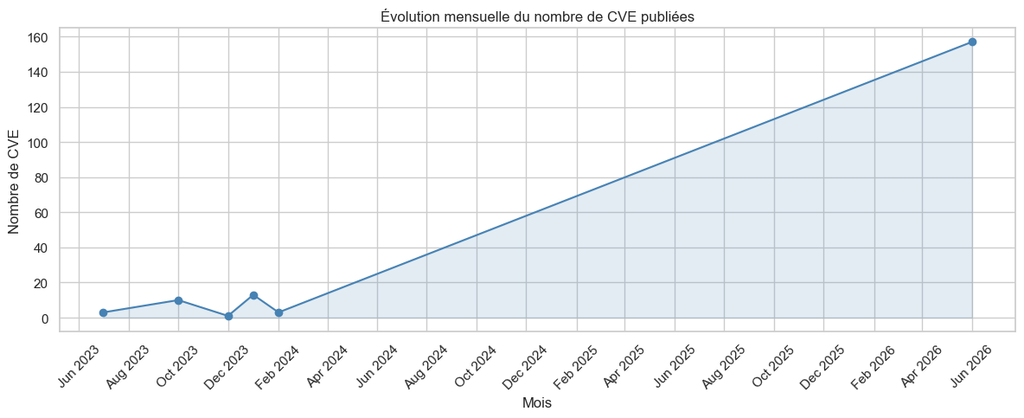

```python
df_time = df.dropna(subset=['Date de publication']).copy()
df_time['Mois'] = df_time['Date de publication'].dt.to_period('M')
par_mois = df_time.groupby('Mois').size().reset_index(name='Nb CVE')
par_mois['Mois'] = par_mois['Mois'].dt.to_timestamp()

fig, ax = plt.subplots(figsize=(12, 5))
ax.plot(par_mois['Mois'], par_mois['Nb CVE'], marker='o', color='steelblue', linewidth=1.5)
ax.fill_between(par_mois['Mois'], par_mois['Nb CVE'], alpha=0.15, color='steelblue')
ax.set_title('Évolution mensuelle du nombre de CVE publiées')
ax.set_xlabel('Mois')
ax.set_ylabel('Nombre de CVE')
ax.xaxis.set_major_formatter(mdates.DateFormatter('%b %Y'))
ax.xaxis.set_major_locator(mdates.MonthLocator(interval=2))
plt.xticks(rotation=45)
plt.tight_layout()
plt.savefig('graphique_evolution_temporelle.png')
plt.show()
```

### 3.10 Courbe cumulative des vulnérabilités

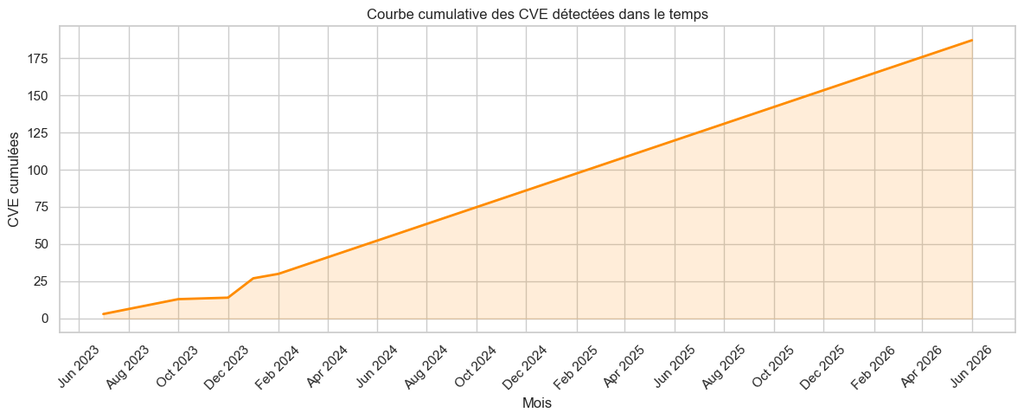

```python
par_mois_cum = par_mois.copy()
par_mois_cum['Cumulé'] = par_mois_cum['Nb CVE'].cumsum()

fig, ax = plt.subplots(figsize=(12, 5))
ax.plot(par_mois_cum['Mois'], par_mois_cum['Cumulé'], color='darkorange', linewidth=2)
ax.fill_between(par_mois_cum['Mois'], par_mois_cum['Cumulé'], alpha=0.15, color='darkorange')
ax.set_title('Courbe cumulative des CVE détectées dans le temps')
ax.set_xlabel('Mois')
ax.set_ylabel('CVE cumulées')
ax.xaxis.set_major_formatter(mdates.DateFormatter('%b %Y'))
ax.xaxis.set_major_locator(mdates.MonthLocator(interval=2))
plt.xticks(rotation=45)
plt.tight_layout()
plt.savefig('graphique_cumul.png')
plt.show()
```

### 3.11 Avis vs Alertes par éditeur (top 8)

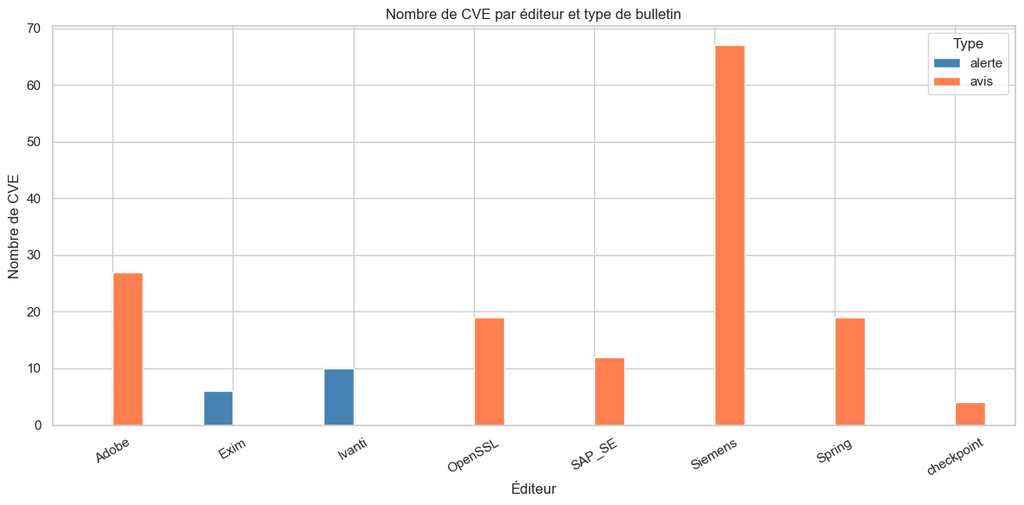

```python
df_type = df[df['Éditeur (Vendor)'].replace('n/a', pd.NA).notna()].copy()
top8_type = df_type['Éditeur (Vendor)'].value_counts().head(8).index
df_type = df_type[df_type['Éditeur (Vendor)'].isin(top8_type)]
pivot = df_type.groupby(['Éditeur (Vendor)', 'Type']).size().unstack(fill_value=0)

fig, ax = plt.subplots(figsize=(12, 6))
pivot.plot(kind='bar', ax=ax, color=['steelblue','coral'], edgecolor='white')
ax.set_title('Nombre de CVE par éditeur et type de bulletin')
ax.set_xlabel('Éditeur')
ax.set_ylabel('Nombre de CVE')
ax.tick_params(axis='x', rotation=30)
ax.legend(title='Type')
plt.tight_layout()
plt.savefig('graphique_avis_vs_alertes.png')
plt.show()
```

### 3.12 Analyse par type de faille CWE (top 10)

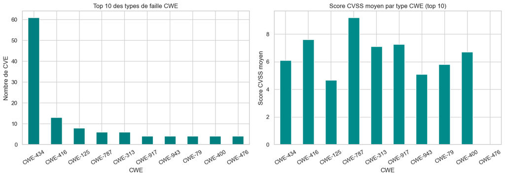

```python
df_cwe = df[~df['Type CWE'].isin(['Non disponible','Non renseigné'])].dropna(subset=['Type CWE'])
top_cwe = df_cwe['Type CWE'].value_counts().head(10)

fig, axes = plt.subplots(1, 2, figsize=(14, 5))

# Barplot
top_cwe.plot(kind='bar', ax=axes[0], color='teal', edgecolor='white')
axes[0].set_title('Top 10 des types de faille CWE')
axes[0].set_xlabel('CWE')
axes[0].set_ylabel('Nombre de CVE')
axes[0].tick_params(axis='x', rotation=30)

# Score CVSS moyen par CWE
df_cwe_cvss = df_cwe[df_cwe['Type CWE'].isin(top_cwe.index)].dropna(subset=['Score CVSS'])
cwe_cvss_moy = df_cwe_cvss.groupby('Type CWE')['Score CVSS'].mean().reindex(top_cwe.index)
cwe_cvss_moy.plot(kind='bar', ax=axes[1], color='darkcyan', edgecolor='white')
axes[1].set_title('Score CVSS moyen par type CWE (top 10)')
axes[1].set_xlabel('CWE')
axes[1].set_ylabel('Score CVSS moyen')
axes[1].tick_params(axis='x', rotation=30)

plt.tight_layout()
plt.savefig('graphique_cwe.png')
plt.show()
```

### 3.13 Nombre de CVE par type de bulletin

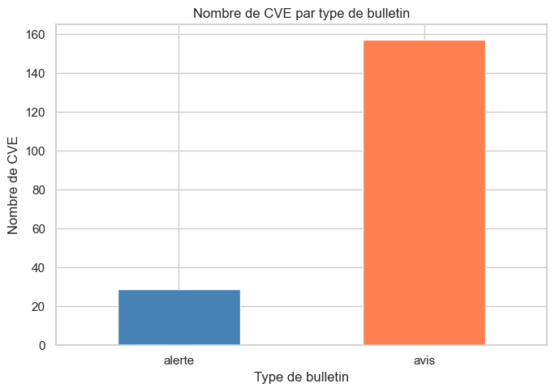

```python
type_bulletin = df.groupby('Type')['Identifiant CVE'].count()
fig, ax = plt.subplots(figsize=(7, 5))
type_bulletin.plot(kind='bar', ax=ax, color=['steelblue','coral'], edgecolor='white')
ax.set_title('Nombre de CVE par type de bulletin')
ax.set_xlabel('Type de bulletin')
ax.set_ylabel('Nombre de CVE')
ax.tick_params(axis='x', rotation=0)
plt.tight_layout()
plt.savefig('graphique_type_bulletin.png')
plt.show()
```

## 4. Machine Learning

Deux modèles sont appliqués aux données enrichies :

- **Non supervisé** : KMeans — regroupement des CVE selon leur profil de risque (CVSS + EPSS)
- **Supervisé** : Random Forest — prédiction du niveau de sévérité à partir des caractéristiques disponibles

### 4.1 Préparation des données ML

```python
df_ml = df[df['Base Severity'].isin(['LOW','MEDIUM','HIGH','CRITICAL'])].copy()
df_ml = df_ml.dropna(subset=['Score CVSS', 'Score EPSS'])

le_cwe = LabelEncoder()
df_ml['CWE_encoded'] = le_cwe.fit_transform(df_ml['Type CWE'].fillna('Inconnu'))

le_severity = LabelEncoder()
df_ml['Severity_encoded'] = le_severity.fit_transform(df_ml['Base Severity'])

print(f'Lignes utilisées pour le ML : {len(df_ml)}')
print(f'Classes de sévérité : {list(le_severity.classes_)}')
```

```
Lignes utilisées pour le ML : 158
Classes de sévérité : ['CRITICAL', 'HIGH', 'LOW', 'MEDIUM']
```

### 4.2 Modèle non supervisé — KMeans

On regroupe les CVE selon leur score CVSS et EPSS sans étiquettes. Le nombre optimal de clusters est déterminé par la méthode du coude (elbow) et le score silhouette.

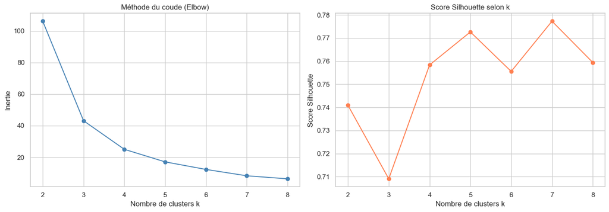

```
k optimal selon silhouette : 7
```

```python
X_kmeans = df_ml[['Score CVSS', 'Score EPSS']].copy()
scaler = StandardScaler()
X_scaled = scaler.fit_transform(X_kmeans)

# Méthode du coude
inerties = []
silhouettes = []
K_range = range(2, 9)
for k in K_range:
    km = KMeans(n_clusters=k, random_state=42, n_init=10)
    labels = km.fit_predict(X_scaled)
    inerties.append(km.inertia_)
    silhouettes.append(silhouette_score(X_scaled, labels))

fig, axes = plt.subplots(1, 2, figsize=(14, 5))

axes[0].plot(K_range, inerties, marker='o', color='steelblue')
axes[0].set_title('Méthode du coude (Elbow)')
axes[0].set_xlabel('Nombre de clusters k')
axes[0].set_ylabel('Inertie')

axes[1].plot(K_range, silhouettes, marker='o', color='coral')
axes[1].set_title('Score Silhouette selon k')
axes[1].set_xlabel('Nombre de clusters k')
axes[1].set_ylabel('Score Silhouette')

plt.tight_layout()
plt.savefig('graphique_elbow_silhouette.png')
plt.show()

k_optimal = K_range[silhouettes.index(max(silhouettes))]
print(f'k optimal selon silhouette : {k_optimal}')
```

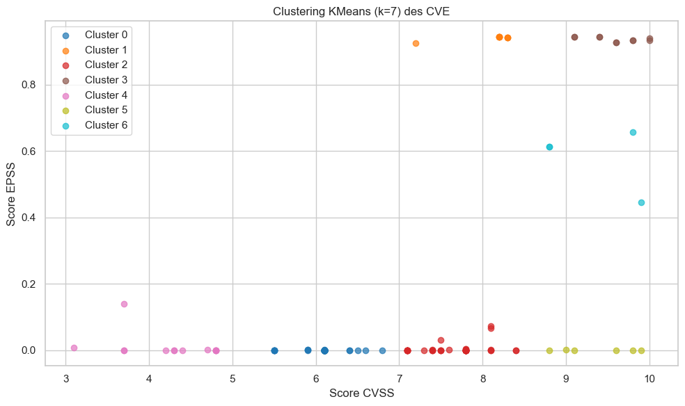

```
Profil moyen par cluster :
         Score CVSS  Score EPSS
Cluster
0             6.082       0.000
1             8.113       0.941
2             7.658       0.005
3             9.580       0.937
4             4.254       0.012
5             9.367       0.000
6             9.325       0.582
```

```python
# Entraînement avec k optimal
kmeans_final = KMeans(n_clusters=k_optimal, random_state=42, n_init=10)
df_ml['Cluster'] = kmeans_final.fit_predict(X_scaled)

palette = plt.cm.get_cmap('tab10', k_optimal)
fig, ax = plt.subplots(figsize=(10, 6))
for i in range(k_optimal):
    groupe = df_ml[df_ml['Cluster'] == i]
    ax.scatter(groupe['Score CVSS'], groupe['Score EPSS'],
               label=f'Cluster {i}', color=palette(i), alpha=0.7)
ax.set_title(f'Clustering KMeans (k={k_optimal}) des CVE')
ax.set_xlabel('Score CVSS')
ax.set_ylabel('Score EPSS')
ax.legend()
plt.tight_layout()
plt.savefig('graphique_kmeans.png')
plt.show()

print('Profil moyen par cluster :')
print(df_ml.groupby('Cluster')[['Score CVSS','Score EPSS']].mean().round(3))
```

### 4.3 Modèle supervisé — Random Forest

On prédit le niveau de sévérité (LOW / MEDIUM / HIGH / CRITICAL) à partir du score CVSS, du score EPSS et du type de faille CWE encodé.

**Justification** : le Random Forest est robuste aux données déséquilibrées, gère bien les features hétérogènes, et fournit un indicateur d'importance des variables facilement interprétable.

```python
X = df_ml[['Score CVSS', 'Score EPSS', 'CWE_encoded']]
y = df_ml['Severity_encoded']

X_train, X_test, y_train, y_test = train_test_split(
    X, y, test_size=0.2, random_state=42, stratify=y
)

clf = RandomForestClassifier(n_estimators=100, random_state=42, class_weight='balanced')
clf.fit(X_train, y_train)
y_pred = clf.predict(X_test)

print('Rapport de classification :')
print(classification_report(
    y_test, y_pred,
    labels=list(range(len(le_severity.classes_))),
    target_names=le_severity.classes_,
    zero_division=0
))
```

```
Rapport de classification :
              precision    recall  f1-score   support

    CRITICAL       1.00      0.75      0.86         4
        HIGH       0.91      1.00      0.95        10
         LOW       0.00      0.00      0.00         1
      MEDIUM       0.94      1.00      0.97        17

    accuracy                           0.94        32
   macro avg       0.71      0.69      0.70        32
weighted avg       0.91      0.94      0.92        32
```

#### Matrice de confusion

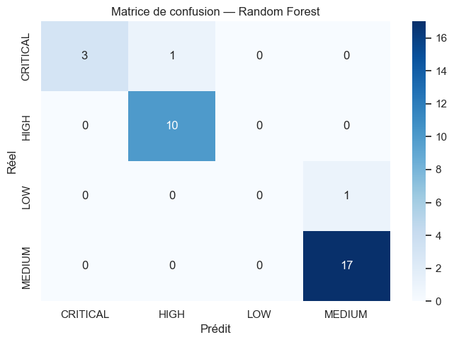

```python
cm = confusion_matrix(y_test, y_pred)
fig, ax = plt.subplots(figsize=(7, 5))
sns.heatmap(cm, annot=True, fmt='d', cmap='Blues', ax=ax,
            xticklabels=le_severity.classes_,
            yticklabels=le_severity.classes_)
ax.set_title('Matrice de confusion — Random Forest')
ax.set_xlabel('Prédit')
ax.set_ylabel('Réel')
plt.tight_layout()
plt.savefig('graphique_confusion_matrix.png')
plt.show()
```

#### Importance des variables

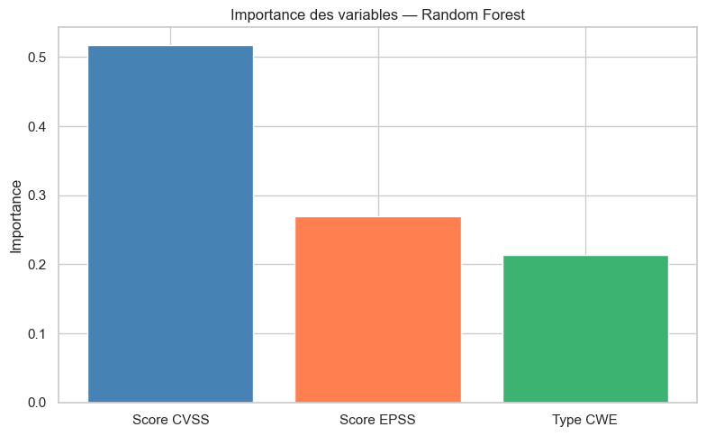

```python
importances = clf.feature_importances_
noms = ['Score CVSS', 'Score EPSS', 'Type CWE']
idx = importances.argsort()[::-1]

fig, ax = plt.subplots(figsize=(8, 5))
ax.bar([noms[i] for i in idx], importances[idx],
       color=['steelblue','coral','mediumseagreen'])
ax.set_title('Importance des variables — Random Forest')
ax.set_ylabel('Importance')
plt.tight_layout()
plt.savefig('graphique_importance_features.png')
plt.show()
```